# bcl_1724326235.htm

[figure not shown]

Practical Machine Learning Course Project

A. Sachin Vianney

October 7, 2018

Executive Summary

Three different Machine learning algorithm are applied to the training set and is used to predict using the test set with varied accuracies.We can infer from the analysis that Random Forest is the best model and is applied to the test set.

We first need to include all the essential libraries/packages

library(ggplot2) library(rattle)

library(caret)

## Loading required package: lattice

library(rpart) library(randomForest)

##

Initailly, we need to download the test and training datasets from the URLs given to us. We set our working directory and proceed with the download followed by reading of the datasets.

#INPUTTING THE DATA training <-

[figure not shown]

read.csv(url("https://d396qusza40orc.cloudfront.net/predmachlearn/pml- training.csv"),header=TRUE)

test <-

read.csv(url("https://d396qusza40orc.cloudfront.net/predmachlearn/pml- testing.csv"),header=TRUE)

Displaying the raw uncleaned data

#DISPLAYING THE RAW DATA

| str(training) |  |  |  |  |  |  |  |
| --- | --- | --- | --- | --- | --- | --- | --- |
| ## 'data.frame': |  |  |  |  | 19622 obs. of | 160 | variables: |
| ## | $ X |  |  |  | : int | 1 | 2 3 4 5 6 7 8 9 10 ... |
| ## | $ user_name |  |  |  | : Factor w/ 6 levels "adelmo","carlitos",..: 2 |  |  |
| 2 2 | 2 2 | 2 2 2 | 2 | 2 ... |  |  |  |

##$ raw_timestamp_part_1 : int 1323084231 1323084231 1323084231 1323084232 1323084232 1323084232 1323084232 1323084232 1323084232 1323084232

...

##$ raw_timestamp_part_2 : int 788290 808298 820366 120339 196328 304277 368296 440390 484323 484434 ...

| ## | $ cvtd_timestamp |  |  | : Factor w/ |  | 20 levels "02/12/2011 13:32",..: 9 |
| --- | --- | --- | --- | --- | --- | --- |
| 9 9 | 9 | 9 9 9 9 9 9 ... |  |  |  |  |
| ## | $ new_window |  |  | : Factor w/ |  | 2 levels "no","yes": 1 1 1 1 1 1 1 |
| 1 1 | 1 ... |  |  |  |  |  |
| ## | $ num_window |  |  | : int | 11 11 11 12 12 12 12 12 12 12 ... |  |
| ## | $ roll_belt |  |  | : num | 1.41 | 1.41 1.42 1.48 1.48 1.45 1.42 1.42 |
| 1.43 1.45 ... |  |  |  |  |  |  |
| ## | $ pitch_belt |  |  | : num | 8.07 | 8.07 8.07 8.05 8.07 8.06 8.09 8.13 |
| 8.16 8.17 ... |  |  |  |  |  |  |
| ## | $ yaw_belt |  |  | : num | -94.4 -94.4 -94.4 -94.4 -94.4 -94.4 - |  |
| 94.4 -94.4 -94.4 -94.4 ... |  |  |  |  |  |  |
| ## | $ total_accel_belt |  |  | : int | 3 3 3 3 3 3 3 3 3 3 ... |  |
| ## | $ kurtosis_roll_belt |  |  | : Factor w/ |  | 397 levels "","-0.016850",..: 1 1 1 |
| 1 1 | 1 1 1 1 1 ... |  |  |  |  |  |
| ## | $ kurtosis_picth_belt |  |  | : Factor w/ 317 levels "","-0.021887",..: 1 1 1 |  |  |
| 1 1 | 1 1 1 1 1 ... |  |  |  |  |  |
| ## | $ kurtosis_yaw_belt |  |  | : Factor w/ |  | 2 levels "","#DIV/0!": 1 1 1 1 1 1 |
| 1 1 | 1 1 ... |  |  |  |  |  |
| ## | $ skewness_roll_belt |  |  | : Factor w/ |  | 395 levels "","-0.003095",..: 1 1 1 |
| 1 1 | 1 1 1 1 |  | 1 ... |  |  |  |
| ## | $ skewness_roll_belt.1 |  |  | : Factor w/ |  | 338 levels "","-0.005928",..: 1 1 1 |
| 1 1 | 1 1 1 1 1 ... |  |  |  |  |  |
| ## | $ skewness_yaw_belt |  |  | : Factor w/ |  | 2 levels "","#DIV/0!": 1 1 1 1 1 1 |
| 1 1 | 1 1 ... |  |  |  |  |  |
| ## | $ max_roll_belt |  |  | : num | NA NA NA NA NA NA NA NA NA NA ... |  |
| ## | $ max_picth_belt |  |  | : int | NA NA NA NA NA NA NA NA NA NA ... |  |
| ## | $ max_yaw_belt |  |  | : Factor w/ |  | 68 levels "","-0.1","-0.2",..: 1 1 |
| 1 1 | 1 1 1 1 1 1 ... |  |  |  |  |  |
| ## | $ min_roll_belt |  |  | : num | NA NA NA NA NA NA NA NA NA NA ... |  |

| ## | $ min_pitch_belt |  | : int | NA NA NA NA NA NA NA NA NA NA ... |  |
| --- | --- | --- | --- | --- | --- |
| ## | $ min_yaw_belt |  | : Factor w/ 68 levels "","-0.1","-0.2",..: 1 1 |  |  |
| 1 1 | 1 | 1 1 1 1 1 ... |  |  |  |
| ## | $ amplitude_roll_belt |  | : num | NA NA NA NA NA NA NA NA NA NA ... |  |
| ## | $ amplitude_pitch_belt |  | : int | NA NA NA NA NA NA NA NA NA NA ... |  |
| ## | $ amplitude_yaw_belt |  | : Factor w/ 4 levels "","#DIV/0!","0.00",..: 1 |  |  |
| 1 1 | 1 | 1 1 1 1 1 1 ... |  |  |  |
| ## | $ var_total_accel_belt |  | : num | NA NA NA NA NA NA NA NA NA NA ... |  |
| ## | $ avg_roll_belt |  | : num | NA NA NA NA NA NA NA NA NA NA ... |  |
| ## | $ stddev_roll_belt |  | : num | NA NA NA NA NA NA NA NA NA NA ... |  |
| ## | $ var_roll_belt |  | : num | NA NA NA NA NA NA NA NA NA NA ... |  |
| ## | $ avg_pitch_belt |  | : num | NA NA NA NA NA NA NA NA NA NA ... |  |
| ## | $ stddev_pitch_belt |  | : num | NA NA NA NA NA NA NA NA NA NA ... |  |
| ## | $ var_pitch_belt |  | : num | NA NA NA NA NA NA NA NA NA NA ... |  |
| ## | $ avg_yaw_belt |  | : num | NA NA NA NA NA NA NA NA NA NA ... |  |
| ## | $ stddev_yaw_belt |  | : num | NA NA NA NA NA NA NA NA NA NA ... |  |
| ## | $ var_yaw_belt |  | : num | NA NA NA NA NA NA NA NA NA NA ... |  |
| ## | $ gyros_belt_x |  | : num | 0 0.02 0 0.02 0.02 0.02 0.02 0.02 | 0.02 |
| 0.03 ... |  |  |  |  |  |
| ## | $ gyros_belt_y |  | : num | 0 0 0 0 0.02 0 0 0 0 0 ... |  |
| ## | $ gyros_belt_z |  | : num | -0.02 -0.02 -0.02 -0.03 -0.02 -0.02 - |  |

0.02 -0.02 -0.02 0 ...

##$ accel_belt_x: int -21 -22 -20 -22 -21 -21 -22 -22 -20 -21

...

| ## | $ accel_belt_y | : | int | 4 4 5 3 2 4 3 4 2 4 ... |
| --- | --- | --- | --- | --- |
| ## | $ accel_belt_z | : | int | 22 22 23 21 24 21 21 21 24 22 ... |

##$ magnet_belt_x: int -3 -7 -2 -6 -6 0 -4 -2 1 -3 ...

##$ magnet_belt_y: int 599 608 600 604 600 603 599 603 602 609

...

##$ magnet_belt_z: int -313 -311 -305 -310 -302 -312 -311 -313 -312 -308 ...

| ## | $ roll_arm | : num | -128 -128 -128 -128 -128 -128 -128 -128 |  |  |  |  |  |  |  |  |  |
| --- | --- | --- | --- | --- | --- | --- | --- | --- | --- | --- | --- | --- |
| -128 -128 ... |  |  |  |  |  |  |  |  |  |  |  |  |
| ## | $ pitch_arm | : num | 22.5 22.5 22.5 |  |  |  |  | 22.1 22.1 22 21.9 21.8 |  |  |  |  |
| 21.7 21.6 ... |  |  |  |  |  |  |  |  |  |  |  |  |
| ## | $ yaw_arm | : num | -161 -161 -161 -161 -161 -161 -161 -161 |  |  |  |  |  |  |  |  |  |
| -161 -161 ... |  |  |  |  |  |  |  |  |  |  |  |  |
| ## | $ total_accel_arm | : int | 34 | 34 | 34 | 34 | 34 | 34 | 34 | 34 | 34 | 34 ... |
| ## | $ var_accel_arm | : num | NA NA NA NA |  |  |  | NA NA |  | NA | NA | NA NA ... |  |
| ## | $ avg_roll_arm | : num | NA NA NA NA |  |  |  | NA NA |  | NA | NA | NA NA ... |  |
| ## | $ stddev_roll_arm | : num | NA NA NA NA |  |  |  | NA NA |  | NA | NA | NA NA ... |  |
| ## | $ var_roll_arm | : num | NA NA NA NA |  |  |  | NA NA |  | NA | NA | NA NA ... |  |
| ## | $ avg_pitch_arm | : num | NA NA NA NA |  |  |  | NA NA |  | NA | NA | NA NA ... |  |
| ## | $ stddev_pitch_arm | : num | NA NA NA NA NA NA NA NA NA NA ... |  |  |  |  |  |  |  |  |  |
| ## | $ var_pitch_arm | : num | NA NA NA NA NA NA NA NA NA NA ... |  |  |  |  |  |  |  |  |  |
| ## | $ avg_yaw_arm | : num | NA NA NA NA NA NA NA NA NA NA ... |  |  |  |  |  |  |  |  |  |
| ## | $ stddev_yaw_arm | : num | NA NA NA NA NA NA NA NA NA NA ... |  |  |  |  |  |  |  |  |  |
| ## | $ var_yaw_arm | : num | NA NA NA NA NA NA NA NA NA NA ... |  |  |  |  |  |  |  |  |  |
| ## | $ gyros_arm_x | : num | 0 0.02 0.02 |  |  |  | 0.02 0 0.02 |  |  |  | 0 0.02 0.02 0.02 |  |
| ... |  |  |  |  |  |  |  |  |  |  |  |  |

[figure not shown]

| ## | $ gyros_arm_y | : num | 0 -0.02 -0.02 -0.03 | -0.03 -0.03 -0.03 - |  |
| --- | --- | --- | --- | --- | --- |
| 0.02 | -0.03 -0.03 ... |  |  |  |  |
| ## | $ gyros_arm_z | : num | -0.02 -0.02 -0.02 0.02 0 |  | 0 0 0 -0.02 - |
| 0.02 ... |  |  |  |  |  |
| ## | $ accel_arm_x | : int | -288 -290 -289 -289 | -289 | -289 -289 -289 |
| -288 | -288 ... |  |  |  |  |
| ## | $ accel_arm_y | : int | 109 110 110 111 111 111 111 111 109 110 |  |  |
| ... |  |  |  |  |  |
| ## | $ accel_arm_z | : int | -123 -125 -126 -123 | -123 | -122 -125 -124 |
| -122 | -124 ... |  |  |  |  |

##$ magnet_arm_x: int -368 -369 -368 -372 -374 -369 -373 -372 -369 -376 ...

| ## | $ magnet_arm_y |  | : int | 337 337 344 344 337 342 336 338 341 334 |  |  |
| --- | --- | --- | --- | --- | --- | --- |
| ... |  |  |  |  |  |  |
| ## | $ magnet_arm_z |  | : int | 516 513 513 512 506 513 509 510 518 516 |  |  |
| ... |  |  |  |  |  |  |
| ## | $ kurtosis_roll_arm |  | : Factor w/ |  | 330 | levels "","-0.02438",..: 1 1 1 |
| 1 1 | 1 | 1 1 1 1 ... |  |  |  |  |
| ## | $ kurtosis_picth_arm |  | : Factor w/ |  | 328 | levels "","-0.00484",..: 1 1 1 |
| 1 1 | 1 | 1 1 1 1 ... |  |  |  |  |
| ## | $ kurtosis_yaw_arm |  | : Factor w/ |  | 395 | levels "","-0.01548",..: 1 1 1 |
| 1 1 | 1 | 1 1 1 1 ... |  |  |  |  |
| ## | $ skewness_roll_arm |  | : Factor w/ |  | 331 | levels "","-0.00051",..: 1 1 1 |
| 1 1 | 1 | 1 1 1 1 ... |  |  |  |  |
| ## | $ skewness_pitch_arm |  | : Factor w/ |  | 328 | levels "","-0.00184",..: 1 1 1 |
| 1 1 | 1 | 1 1 1 1 ... |  |  |  |  |
| ## | $ skewness_yaw_arm |  | : Factor w/ |  | 395 | levels "","-0.00311",..: 1 1 1 |
| 1 1 | 1 | 1 1 1 1 ... |  |  |  |  |
| ## | $ max_roll_arm |  | : num | NA NA NA NA NA NA NA NA NA NA ... |  |  |
| ## | $ max_picth_arm |  | : num | NA NA NA NA NA NA NA NA NA NA ... |  |  |
| ## | $ max_yaw_arm |  | : int | NA NA NA NA NA NA NA NA NA NA ... |  |  |
| ## | $ min_roll_arm |  | : num | NA NA NA NA NA NA NA NA NA NA ... |  |  |
| ## | $ min_pitch_arm |  | : num | NA NA NA NA NA NA NA NA NA NA ... |  |  |
| ## | $ min_yaw_arm |  | : int | NA NA NA NA NA NA NA NA NA NA ... |  |  |
| ## | $ amplitude_roll_arm |  | : num | NA NA NA NA NA NA NA NA NA NA ... |  |  |
| ## | $ amplitude_pitch_arm |  | : num | NA NA NA NA NA NA NA NA NA NA ... |  |  |
| ## | $ amplitude_yaw_arm |  | : int | NA NA NA NA NA NA NA NA NA NA ... |  |  |
| ## | $ roll_dumbbell |  | : num | 13.1 | 13.1 12.9 13.4 13.4 ... |  |
| ## | $ pitch_dumbbell |  | : num | -70.5 -70.6 -70.3 -70.4 -70.4 ... |  |  |
| ## | $ yaw_dumbbell |  | : num | -84.9 -84.7 -85.1 -84.9 -84.9 ... |  |  |

##$ kurtosis_roll_dumbbell : Factor w/ 398 levels "","-0.0035","- 0.0073",..: 1 1 1 1 1 1 1 1 1 1 ...

##$ kurtosis_picth_dumbbell : Factor w/ 401 levels "","-0.0163","- 0.0233",..: 1 1 1 1 1 1 1 1 1 1 ...

| ## | $ | kurtosis_yaw_dumbbell : Factor w/ 2 levels "","#DIV/0!": 1 1 1 1 1 1 |
| --- | --- | --- |
| 1 1 | 1 | 1 ... |

##$ skewness_roll_dumbbell : Factor w/ 401 levels "","-0.0082","- 0.0096",..: 1 1 1 1 1 1 1 1 1 1 ...

##$ skewness_pitch_dumbbell : Factor w/ 402 levels "","-0.0053","- 0.0084",..: 1 1 1 1 1 1 1 1 1 1 ...

[figure not shown]

| ## | $ skewness_yaw_dumbbell |  |  | : Factor w/ 2 levels "","#DIV/0!": 1 1 1 1 1 1 |  |
| --- | --- | --- | --- | --- | --- |
| 1 1 | 1 | 1 ... |  |  |  |
| ## | $ max_roll_dumbbell |  |  | : num | NA NA NA NA NA NA NA NA NA NA ... |
| ## | $ max_picth_dumbbell |  |  | : num | NA NA NA NA NA NA NA NA NA NA ... |
| ## | $ max_yaw_dumbbell |  |  | : Factor w/ 73 levels "","-0.1","-0.2",..: 1 1 |  |
| 1 1 | 1 | 1 | 1 1 1 1 ... |  |  |
| ## | $ min_roll_dumbbell |  |  | : num | NA NA NA NA NA NA NA NA NA NA ... |
| ## | $ min_pitch_dumbbell |  |  | : num | NA NA NA NA NA NA NA NA NA NA ... |
| ## | $ min_yaw_dumbbell |  |  | : Factor w/ 73 levels "","-0.1","-0.2",..: 1 1 |  |
| 1 1 | 1 1 1 1 1 1 ... |  |  |  |  |
| ## | $ amplitude_roll_dumbbell : num |  |  |  | NA NA NA NA NA NA NA NA NA NA ... |
| ## |  | [list output truncated] |  |  |  |

As we can see, there are a lot of NA values, we need to clean this data in order to make our analysis easier and more meaningful

#DATA CLEANING

na_count <- sapply(test, function(y) sum((is.na(y)))) na <- na_count[na_count == 20]

good <- names(na)

training <- training[,!(names(training) %in% good)] test <- test[,!(names(test) %in% good)]

good2 <- c('user_name','raw_timestamp_part_1', 'raw_timestamp_part_2', 'cvtd_timestamp', 'new_window', 'num_window', 'X')

training <- training[,!(names(training) %in% good2)] test <- test[,!(names(test) %in% good2)]

#DISPLAYING THE CLEAN DATA

| str(training) |  |  |  |  |  |  |  |  |  |  |  |  |
| --- | --- | --- | --- | --- | --- | --- | --- | --- | --- | --- | --- | --- |
| ## 'data.frame': |  |  | 19622 | obs. of | 53 | variables: |  |  |  |  |  |  |
| ## | $ roll_belt |  |  | : num | 1.41 | 1.41 | 1.42 | 1.48 | 1.48 1.45 | 1.42 | 1.42 | 1.43 |
| 1.45 ... |  |  |  |  |  |  |  |  |  |  |  |  |
| ## | $ pitch_belt |  |  | : num | 8.07 | 8.07 | 8.07 | 8.05 | 8.07 8.06 | 8.09 | 8.13 | 8.16 |
| 8.17 ... |  |  |  |  |  |  |  |  |  |  |  |  |
| ## | $ yaw_belt |  |  | : num | -94.4 -94.4 -94.4 -94.4 -94.4 -94.4 -94.4 - |  |  |  |  |  |  |  |
| 94.4 -94.4 -94.4 ... |  |  |  |  |  |  |  |  |  |  |  |  |
| ## | $ total_accel_belt |  |  | : int | 3 3 3 3 3 |  | 3 3 3 | 3 3 ... |  |  |  |  |

##$ gyros_belt_x : num 0 0.02 0 0.02 0.02 0.02 0.02 0.02 0.02 0.03

...

##$ gyros_belt_y : num 0 0 0 0 0.02 0 0 0 0 0 ...

##$ gyros_belt_z : num -0.02 -0.02 -0.02 -0.03 -0.02 -0.02 -0.02 - 0.02 -0.02 0 ...

##$ accel_belt_x : int -21 -22 -20 -22 -21 -21 -22 -22 -20 -21 ...

##$ accel_belt_y : int 4 4 5 3 2 4 3 4 2 4 ...

##$ accel_belt_z : int 22 22 23 21 24 21 21 21 24 22 ...

##$ magnet_belt_x : int -3 -7 -2 -6 -6 0 -4 -2 1 -3 ...

##$ magnet_belt_y : int 599 608 600 604 600 603 599 603 602 609 ...

##$ magnet_belt_z : int -313 -311 -305 -310 -302 -312 -311 -313 -312 -308 ...

| ## | $ roll_arm | : num | -128 -128 -128 | -128 -128 -128 -128 | -128 | -128 |
| --- | --- | --- | --- | --- | --- | --- |
| -128 ... |  |  |  |  |  |  |
| ## | $ pitch_arm | : num | 22.5 22.5 22.5 | 22.1 22.1 22 21.9 21.8 21.7 |  |  |
| 21.6 ... |  |  |  |  |  |  |
| ## | $ yaw_arm | : num | -161 -161 -161 | -161 -161 -161 -161 | -161 | -161 |
| -161 ... |  |  |  |  |  |  |
| ## | $ total_accel_arm | : int | 34 34 34 34 34 | 34 34 34 34 34 ... |  |  |

##$ gyros_arm_x : num 0 0.02 0.02 0.02 0 0.02 0 0.02 0.02 0.02 ...

##$ gyros_arm_y : num 0 -0.02 -0.02 -0.03 -0.03 -0.03 -0.03 -0.02 -0.03 -0.03 ...

##$ gyros_arm_z : num -0.02 -0.02 -0.02 0.02 0 0 0 0 -0.02 -0.02

...

##$ accel_arm_x : int -288 -290 -289 -289 -289 -289 -289 -289 -288 -288 ...

##$ accel_arm_y : int 109 110 110 111 111 111 111 111 109 110 ...

##$ accel_arm_z : int -123 -125 -126 -123 -123 -122 -125 -124 -122 -124 ...

##$ magnet_arm_x : int -368 -369 -368 -372 -374 -369 -373 -372 -369 -376 ...

##$ magnet_arm_y : int 337 337 344 344 337 342 336 338 341 334 ...

##$ magnet_arm_z : int 516 513 513 512 506 513 509 510 518 516 ...

| ## | $ roll_dumbbell | : num | 13.1 13.1 12.9 13.4 13.4 ... |  |  |  |  |
| --- | --- | --- | --- | --- | --- | --- | --- |
| ## | $ pitch_dumbbell | : num | -70.5 | -70.6 | -70.3 | -70.4 | -70.4 ... |
| ## | $ yaw_dumbbell | : num | -84.9 | -84.7 | -85.1 | -84.9 | -84.9 ... |

##$ total_accel_dumbbell: int 37 37 37 37 37 37 37 37 37 37 ...

##$ gyros_dumbbell_x : num 0 0 0 0 0 0 0 0 0 0 ...

##$ gyros_dumbbell_y : num -0.02 -0.02 -0.02 -0.02 -0.02 -0.02 -0.02 - 0.02 -0.02 -0.02 ...

##$ gyros_dumbbell_z : num 0 0 0 -0.02 0 0 0 0 0 0 ...

##$ accel_dumbbell_x : int -234 -233 -232 -232 -233 -234 -232 -234 -232 -235 ...

##$ accel_dumbbell_y : int 47 47 46 48 48 48 47 46 47 48 ...

##$ accel_dumbbell_z : int -271 -269 -270 -269 -270 -269 -270 -272 -269 -270 ...

## $ magnet_dumbbell_x : int -559 -555 -561 -552 -554 -558 -551 -555 -549

-558 ...

##$ magnet_dumbbell_y : int 293 296 298 303 292 294 295 300 292 291 ...

| ## | $ magnet_dumbbell_z | : num | -65 -64 -63 -60 -68 -66 -70 -74 -65 -69 ... |  |
| --- | --- | --- | --- | --- |
| ## | $ roll_forearm | : num | 28.4 28.3 28.3 28.1 28 27.9 27.9 27.8 27.7 |  |
| 27.7 ... |  |  |  |  |
| ## | $ pitch_forearm | : num | -63.9 -63.9 -63.9 -63.9 -63.9 | -63.9 -63.9 - |
| 63.8 -63.8 -63.8 ... |  |  |  |  |
| ## | $ yaw_forearm | : num | -153 -153 -152 -152 -152 -152 | -152 -152 -152 |
| -152 ... |  |  |  |  |

##$ total_accel_forearm : int 36 36 36 36 36 36 36 36 36 36 ...

##$ gyros_forearm_x : num 0.03 0.02 0.03 0.02 0.02 0.02 0.02 0.02 0.03 0.02 ...

[figure not shown]

##$ gyros_forearm_y : num 0 0 -0.02 -0.02 0 -0.02 0 -0.02 0 0 ...

##$ gyros_forearm_z : num -0.02 -0.02 0 0 -0.02 -0.03 -0.02 0 -0.02 - 0.02 ...

##$ accel_forearm_x : int 192 192 196 189 189 193 195 193 193 190 ...

##$ accel_forearm_y : int 203 203 204 206 206 203 205 205 204 205 ...

##$ accel_forearm_z : int -215 -216 -213 -214 -214 -215 -215 -213 -214 -215 ...

##$ magnet_forearm_x : int -17 -18 -18 -16 -17 -9 -18 -9 -16 -22 ...

##$ magnet_forearm_y : num 654 661 658 658 655 660 659 660 653 656 ...

##$ magnet_forearm_z : num 476 473 469 469 473 478 470 474 476 473 ...

| ## | $ | classe | : Factor w/ 5 levels "A","B","C","D",..: 1 1 1 1 1 |
| --- | --- | --- | --- |
| 1 1 | 1 | 1 1 ... |  |

Machine Learning Algorithms

For this analysis, we will be using three algorithmic approaches The Three algorithms applied are: 1)Decision Tree 2)Random Forest 3)Generalized Boosted Regression

#MACHINE LEARNING ALGORITHMS IMPLEMENTATION

set.seed(49)

part <- createDataPartition(training$classe, p = 0.75, list = FALSE) training1 <- training[part,]

test1 <- training[-part,]

I have used the cross-validation technique in order to improve efficiency and limit overfitting.I have used 10 folds.

tr_cont <- trainControl(method="cv", number=10)

Descision Trees

model1 <- train(classe~., data=training1, method="rpart", trControl=tr_cont) fancyRpartPlot(model1$finalModel)

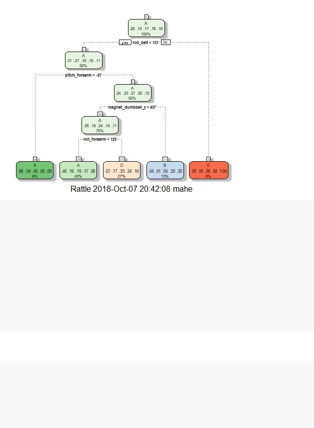

prediction1 <- predict(model1,newdata=test1)

conf_mat1 <- confusionMatrix(test1$classe,prediction1) conf_mat1$table

##Reference

| ## Prediction |  | A | B | C | D | E |
| --- | --- | --- | --- | --- | --- | --- |
| ## | A 1267 |  | 22 | 98 | 0 | 8 |
| ## | B | 398 | 332 | 219 | 0 | 0 |
| ## | C | 396 | 35 | 424 | 0 | 0 |
| ## | D | 352 | 168 | 284 | 0 | 0 |
| ## | E | 140 | 123 | 235 | 0 | 403 |

conf_mat1$overall[1]

##Accuracy

##0.4946982

Random Forest

model2 <- train(classe~., data=training1, method="rf",trControl=tr_cont,verbose = FALSE) print(model2)

##Random Forest

##14718 samples

##52 predictor

[figure not shown]

##5 classes: 'A', 'B', 'C', 'D', 'E'

##No pre-processing

##Resampling: Cross-Validated (10 fold)

##Summary of sample sizes: 13246, 13248, 13246, 13246, 13245, 13246, ...

##Resampling results across tuning parameters:

##

##mtry Accuracy Kappa

##2 0.9925262 0.9905445

##27 0.9927292 0.9908018

##52 0.9880410 0.9848702

##Accuracy was used to select the optimal model using the largest value.

##The final value used for the model was mtry = 27.

prediction2 <- predict(model2,newdata=test1)

conf_mat2 <- confusionMatrix(test1$classe,prediction2) conf_mat2$table

##Reference

| ## Prediction |  | A | B | C | D | E |
| --- | --- | --- | --- | --- | --- | --- |
| ## | A 1394 |  | 1 | 0 | 0 | 0 |
| ## | B | 9 | 939 | 1 | 0 | 0 |
| ## | C | 0 | 7 | 846 | 2 | 0 |
| ## | D | 0 | 1 | 4 | 798 | 1 |
| ## | E | 0 | 1 | 2 | 1 | 897 |

conf_mat2$overall[1]

##Accuracy

##0.9938825

Generalized Boosted Regression

model3 <- train(classe~., data=training1, method="gbm", trControl=tr_cont, verbose=FALSE)

print(model3)

##Stochastic Gradient Boosting

##14718 samples

##52 predictor

##5 classes: 'A', 'B', 'C', 'D', 'E'

##No pre-processing

##Resampling: Cross-Validated (10 fold)

##Summary of sample sizes: 13247, 13248, 13246, 13245, 13246, 13245, ...

##Resampling results across tuning parameters:

##

##interaction.depth n.trees Accuracy Kappa

| ## 1 | 50 | 0.7576432 0.6927629 |
| --- | --- | --- |

[figure not shown]

| ## | 1 | 100 | 0.8187920 | 0.7706153 |
| --- | --- | --- | --- | --- |
| ## | 1 | 150 | 0.8537841 | 0.8149065 |
| ## | 2 | 50 | 0.8543951 | 0.8155150 |
| ## | 2 | 100 | 0.9075262 | 0.8829763 |
| ## | 2 | 150 | 0.9298819 | 0.9112773 |
| ## | 3 | 50 | 0.8980840 | 0.8709724 |
| ## | 3 | 100 | 0.9415677 | 0.9260695 |
| ## | 3 | 150 | 0.9629701 | 0.9531596 |
| ## |  |  |  |  |

##Tuning parameter 'shrinkage' was held constant at a value of 0.1

##Tuning parameter 'n.minobsinnode' was held constant at a value of 10

##Accuracy was used to select the optimal model using the largest value.

##The final values used for the model were n.trees = 150,

##interaction.depth = 3, shrinkage = 0.1 and n.minobsinnode = 10.

prediction3 <- predict(model3,newdata=test1)

conf_mat3 <- confusionMatrix(test1$classe,prediction3) conf_mat3$table

##Reference

| ## Prediction |  | A | B | C | D | E |
| --- | --- | --- | --- | --- | --- | --- |
| ## | A 1375 |  | 16 | 4 | 0 | 0 |
| ## | B | 36 | 888 | 24 | 0 | 1 |
| ## | C | 0 | 28 | 816 | 8 | 3 |
| ## | D | 0 | 5 | 19 | 777 | 3 |

##E 3 13 10 18 857 conf_mat3$overall[1]

##Accuracy

##0.9610522

The Final Result/Prediction

final <- predict(model2,newdata= test) final

##[1] B A B A A E D B A A B C B A E E A B B B

##Levels: A B C D E